# Final class 4.3 - Article analysis

Author

Student

Published

October 14, 2026

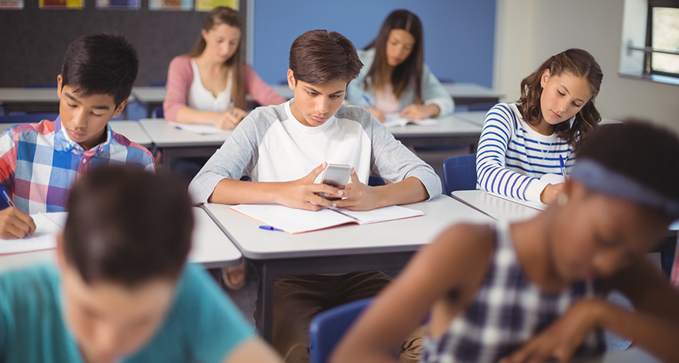

# Instructions

Please answer the following questions regarding [this study on microcommitments](https://pubs.aeaweb.org/doi/pdf/10.1257/pandp.20211043). You will need your VPN on to access the study online.

## Objective of the study

- Summarize the larger issue that the article is trying to understand.

## Study protocol

- Please describe how the data is collected, what the sample size is, the specific response variable definition, what predictor variables were measured, and a summary of the nonresponse.
- What problems, if any, do you see with this study given the study protocol?
- Does the protocol provide a good test of the hypotheses? Why or why not?
- Do you agree with how the variables are defined to match the study concepts?

## Summary data

- What does the summary data indicate about the hypotheses?
- How easy is it, in your opinion, to generalize the result of this sample to other situations and contexts?

## Inference analysis

- Are the conditions for regression met for Tables 2 and 3? How do you know?
- Interpret the coefficients in Table 2 - is the magnitude of the coefficients large or small? What are the units?
- Can you think of any lurking variables missing from these regressions?

## Discussion and conclusion

- How serious do you think the limitations of this study are? Can you think of other limitations?
- Do you feel the conclusion did a good job summarizing the statistical results?

## Additional questions

- What are some areas that you felt the author(s) of the study were unclear on?
- What connections between the results and the argument were unclear?
- Write around 3 additional questions you still have after doing a careful analysis of the article.